# PLS - Hoteles

Artículo 1, versión 1 (Doctoranda Moreno)

Roberto Gil-Saura

2021-06-02

# 1 Análisis del modelo de medida. Modelización con moderación

Seguidamente mostramos el modelo de medida (outer model) y el modelo estructural (inner model), establecidos a partir de las hipótesis lanzadas.

El modelo estructural es el siguiente:

[interactive chart not shown]

Modelo estructural

## 1.1 Fiabilidad del instrumento de medida

Para el modelo de medida se han considerado constructos de tipo composite mode_A (reflectivos). De este modo, el primer paso debe ser observar el resumen de los indicadores de fiabilidad, consistencia interna y validez.

```
    alpha  rhoC   AVE  rhoA
ICT 0.855 0.903 0.700 0.856
SUS 0.926 0.935 0.514 0.950
BEQ 0.954 0.966 0.876 0.986
RVL 0.860 0.896 0.632 0.902
SST 0.856 0.912 0.777 0.876
EST 0.825 0.896 0.742 0.833

Alpha, rhoC, and rhoA should exceed 0.7 while AVE should exceed 0.5
```

El resultado del análisis muestra todas las escalas que apoyan las variables latentes tienen un *Cronbach’s alpha* mayor que 0.7, completado por una fiabilidad del compuesto *rhoC* también por encima de 0.7. para valores superiores a 0.9[^1].

## 1.2 Validez convergente

### 1.2.1 AVE (reflectivos)

Del mismo modo, para evaluar la *validez convergente* o grado con el que una medida correlaciona positivamente con medidas alternativas del mismo constructo, usamos el coeficiente *AVE (average variance extracted)* que también cumple con la expectativa de estar por encima de 0.5.

```
  ICT   SUS   BEQ   RVL   SST   EST
0.700 0.514 0.876 0.632 0.777 0.742
```

Los indicadores son mostrados de forma conjunta en el siguiente gráfico.

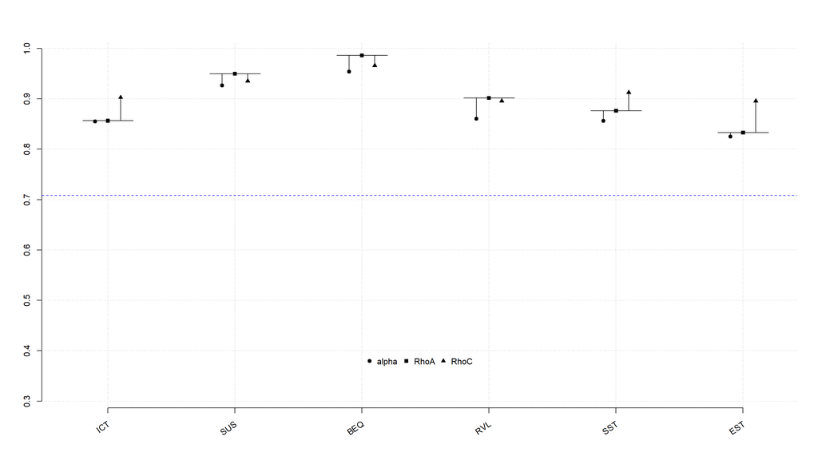

Tabla de fiabilidad

### 1.2.2 Análisis de las cargas (reflectivos) o de los pesos (formativos)

Por otro lado, es importante analizar también las cargas o *loadings*, indicadores de la fiabilidad del indicador en el constructo, y que deberían ser mayores de 0.7 para retener el indicador; para aquellas que están entre 0.4 y 0.7 debe ser analizado el comportamiento del constructo ante una eliminación del indicador con carga baja[^2].

```
        ICT   SUS   BEQ   RVL   SST   EST
ICT1  0.854 0.000 0.000 0.000 0.000 0.000
ICT2  0.884 0.000 0.000 0.000 0.000 0.000
ICT3  0.855 0.000 0.000 0.000 0.000 0.000
ICT4  0.747 0.000 0.000 0.000 0.000 0.000
SUS1  0.000 0.769 0.000 0.000 0.000 0.000
SUS2  0.000 0.807 0.000 0.000 0.000 0.000
SUS3  0.000 0.761 0.000 0.000 0.000 0.000
SUS4  0.000 0.724 0.000 0.000 0.000 0.000
SUS5  0.000 0.680 0.000 0.000 0.000 0.000
SUS6  0.000 0.806 0.000 0.000 0.000 0.000
SUS7  0.000 0.698 0.000 0.000 0.000 0.000
SUS8  0.000 0.674 0.000 0.000 0.000 0.000
SUS10 0.000 0.805 0.000 0.000 0.000 0.000
SUS11 0.000 0.841 0.000 0.000 0.000 0.000
SUS12 0.000 0.817 0.000 0.000 0.000 0.000
SUS13 0.000 0.511 0.000 0.000 0.000 0.000
SUS14 0.000 0.477 0.000 0.000 0.000 0.000
SUS15 0.000 0.531 0.000 0.000 0.000 0.000
BEQ7  0.000 0.000 0.909 0.000 0.000 0.000
BEQ8  0.000 0.000 0.931 0.000 0.000 0.000
BEQ9  0.000 0.000 0.951 0.000 0.000 0.000
BEQ10 0.000 0.000 0.952 0.000 0.000 0.000
RVL1  0.000 0.000 0.000 0.780 0.000 0.000
RVL2  0.000 0.000 0.000 0.783 0.000 0.000
RVL3  0.000 0.000 0.000 0.819 0.000 0.000
RVL4  0.000 0.000 0.000 0.778 0.000 0.000
RVL5  0.000 0.000 0.000 0.814 0.000 0.000
SST1  0.000 0.000 0.000 0.000 0.815 0.000
SST2  0.000 0.000 0.000 0.000 0.931 0.000
SST3  0.000 0.000 0.000 0.000 0.895 0.000
EST1  0.000 0.000 0.000 0.000 0.000 0.858
EST2  0.000 0.000 0.000 0.000 0.000 0.904
EST3  0.000 0.000 0.000 0.000 0.000 0.819
```

## 1.3 Validez discriminante

### 1.3.1 Cross-loadings

Para el análisis de la validez discriminante o capacidad de un constructo de ser realmente distinto a otros, utilizamos las denominadas *cross-loadings*, que miden esa capacidad del constructo. En la tabla adjunta se puede observar en cada indicador carga de forma superior en su variable latente, siendo el resto de cargas de menor intensidad.

```
        ICT   SUS   BEQ   RVL   SST   EST
ICT1  0.854 0.366 0.132 0.250 0.127 0.081
ICT2  0.884 0.388 0.237 0.286 0.168 0.110
ICT3  0.855 0.372 0.278 0.252 0.109 0.011
ICT4  0.747 0.365 0.131 0.264 0.175 0.051
SUS1  0.282 0.769 0.168 0.339 0.224 0.218
SUS2  0.339 0.807 0.148 0.344 0.173 0.162
SUS3  0.302 0.761 0.043 0.299 0.203 0.143
SUS4  0.286 0.724 0.112 0.294 0.237 0.195
SUS5  0.250 0.680 0.170 0.178 0.198 0.112
SUS6  0.347 0.806 0.182 0.233 0.230 0.104
SUS7  0.323 0.698 0.169 0.251 0.103 0.035
SUS8  0.274 0.674 0.116 0.380 0.164 0.151
SUS10 0.420 0.805 0.211 0.378 0.298 0.201
SUS11 0.434 0.841 0.265 0.371 0.308 0.214
SUS12 0.438 0.817 0.312 0.323 0.344 0.214
SUS13 0.135 0.511 0.026 0.283 0.126 0.104
SUS14 0.176 0.477 0.052 0.275 0.144 0.140
SUS15 0.225 0.531 0.044 0.331 0.101 0.084
BEQ7  0.207 0.237 0.909 0.183 0.323 0.336
BEQ8  0.179 0.152 0.931 0.064 0.268 0.277
BEQ9  0.230 0.203 0.951 0.078 0.259 0.276
BEQ10 0.249 0.237 0.952 0.092 0.276 0.248
RVL1  0.187 0.330 0.032 0.780 0.096 0.207
RVL2  0.205 0.304 0.033 0.783 0.096 0.238
RVL3  0.241 0.265 0.118 0.819 0.008 0.103
RVL4  0.215 0.317 0.094 0.778 0.025 0.123
RVL5  0.338 0.419 0.144 0.814 0.037 0.122
SST1  0.212 0.297 0.271 0.052 0.815 0.557
SST2  0.140 0.283 0.240 0.047 0.931 0.725
SST3  0.122 0.230 0.299 0.051 0.895 0.738
EST1  0.039 0.161 0.223 0.142 0.631 0.858
EST2  0.118 0.227 0.246 0.156 0.726 0.904
EST3  0.031 0.155 0.331 0.178 0.631 0.819
```

### 1.3.2 Fornell-Larcker

El criterio de Fornell-Larcker, compara la raíz cuadrado del *AVE* con la correlación de las variables latentes. La raíz cuadrada del AVE de cada constructo, debería ser más grande que la más alta correlación con cualquier otro constructo. Se puede observar en la tabla siguiente que el valor en la diagonal principal, es mayor que el resto de valores en la parte inferior de la matriz.

```
      ICT   SUS   BEQ   RVL   SST   EST
ICT 0.836     .     .     .     .     .
SUS 0.447 0.717     .     .     .     .
BEQ 0.234 0.229 0.936     .     .     .
RVL 0.315 0.420 0.121 0.795     .     .
SST 0.173 0.302 0.305 0.056 0.881     .
EST 0.076 0.212 0.308 0.184 0.772 0.861

FL Criteria table reports square root of AVE on the diagonal and construct correlations on the lower triangle.
```

### 1.3.3 HTMT

Por último el HTMT es un ratio que si es mayor que 0.90 indica una pérdida de validez discriminante.

```
      ICT   SUS   BEQ   RVL   SST EST
ICT     .     .     .     .     .   .
SUS 0.476     .     .     .     .   .
BEQ 0.254 0.206     .     .     .   .
RVL 0.345 0.471 0.115     .     .   .
SST 0.210 0.325 0.334 0.086     .   .
EST 0.098 0.236 0.344 0.236 0.907   .
```

El ratio HTMT nos indica que los indicadores que pertenecen a una determinada variables latente están correlacionando más como otra variable latente que con la propia. HT/MT> 0.85 Clark & Watson, > 0.90 Gold et al. 2001; Teo et al. 2008).

**Atención SST con EST tiene un valor de 0.907!!!**

# 2 Análisis del modelo estructural

Una vez analizados los constructos desde el punto de vista de su composición, debemos analizar el modelo estructural en su conjunto. Partiendo de que el objetivo del PLS es la maximización de la varianza explicada, las medidas más importantes son la fiabilidad, la validez convergente y la validez discriminante del conjunto del modelo.

- Paths o cargas de latentes…
- R<sup>2</sup>, coeficiente de determinación y/o % de varianza explicada
- f<sup>2</sup> y q<sup>2</sup> efecto tamaño
- Q<sup>2</sup>, relevancia predictiva

## 2.1 Paths y R<sup>2</sup>

```
         SUS   BEQ   RVL    SST   EST
R^2    0.199 0.053 0.015  0.003 0.596
AdjR^2 0.196 0.049 0.011 -0.001 0.594
ICT    0.447     .     .      .     .
SUS        . 0.229     .      .     .
BEQ        .     . 0.121      .     .
RVL        .     .     .  0.056     .
SST        .     .     .      . 0.772
```

Buscar R<sup>2</sup> mayores de 0.7, aunque valores alrededor de 0.25 sean aceptados según ámbitos; (sustancial mayor que 0.75, moderado alrededor de 0.5 y débil, 0.25). Usar R<sup>2</sup><sub>adj</sub> para comparar modelos con diferente número de constructos y/u observaciones.

## 2.2 f<sup>2</sup> - effect sizes

El f<sup>2</sup> permite evaluar la contribución de cada constructo exógeno a la R<sup>2</sup> de un constructo endógeno. Los valores de 0.02, 0.15 y 0.35 indican un efecto pequeño, mediano o grande sobre el constructo endógeno.

```
      ICT   SUS   BEQ   RVL   SST   EST
ICT 0.000 0.249 0.000 0.000 0.000 0.000
SUS 0.000 0.000 0.055 0.000 0.000 0.000
BEQ 0.000 0.000 0.000 0.015 0.000 0.000
RVL 0.000 0.000 0.000 0.000 0.003 0.000
SST 0.000 0.000 0.000 0.000 0.000 1.473
EST 0.000 0.000 0.000 0.000 0.000 0.000
```

## 2.3 Efectos

### 2.3.1 Totales

```
      ICT   SUS   BEQ   RVL   SST   EST
ICT 0.000 0.447 0.102 0.012 0.001 0.001
SUS 0.000 0.000 0.229 0.028 0.002 0.001
BEQ 0.000 0.000 0.000 0.121 0.007 0.005
RVL 0.000 0.000 0.000 0.000 0.056 0.044
SST 0.000 0.000 0.000 0.000 0.000 0.772
EST 0.000 0.000 0.000 0.000 0.000 0.000
```

### 2.3.2 Indirectos

```
      ICT   SUS   BEQ   RVL   SST   EST
ICT 0.000 0.000 0.102 0.012 0.001 0.001
SUS 0.000 0.000 0.000 0.028 0.002 0.001
BEQ 0.000 0.000 0.000 0.000 0.007 0.005
RVL 0.000 0.000 0.000 0.000 0.000 0.044
SST 0.000 0.000 0.000 0.000 0.000 0.000
EST 0.000 0.000 0.000 0.000 0.000 0.000
```

### 2.3.3 it_criteria

```
        SUS     BEQ    RVL   SST      EST
AIC -56.626 -11.463 -0.934 2.144 -239.684
BIC -49.444  -4.281  6.248 9.326 -232.502
```

# 3 Modelización con bootstrapping

*Bootstrapping* para calcular la significatividad de los paths estimados. Habitualmente se trabaja con un 5% (t > 1.96) lo que implica significatividad al 95%. Podemos cambiar al 10 o al 1 según ámbito. Usar doble *bootstrapping* si hay menos de 4 constructos.

## 3.1 Structural paths

```
             Original Est. Bootstrap Mean Bootstrap SD T Stat. 2.5% CI 97.5% CI
ICT  ->  SUS         0.447          0.455        0.058   7.766   0.339    0.557
SUS  ->  BEQ         0.229          0.244        0.064   3.586   0.131    0.359
BEQ  ->  RVL         0.121          0.145        0.071   1.689   0.005    0.274
RVL  ->  SST         0.056          0.056        0.081   0.699  -0.127    0.192
SST  ->  EST         0.772          0.770        0.034  22.976   0.717    0.834
```

## 3.2 Bootstrapped loadings

```
               Original Est. Bootstrap Mean Bootstrap SD T Stat. 2.5% CI 97.5% CI
ICT1  ->  ICT          0.854          0.848        0.023  36.511   0.798    0.894
ICT2  ->  ICT          0.884          0.884        0.017  51.702   0.844    0.912
ICT3  ->  ICT          0.855          0.851        0.023  37.349   0.797    0.885
ICT4  ->  ICT          0.747          0.738        0.041  18.339   0.649    0.814
SUS1  ->  SUS          0.769          0.763        0.038  20.393   0.684    0.825
SUS2  ->  SUS          0.807          0.802        0.036  22.627   0.731    0.859
SUS3  ->  SUS          0.761          0.757        0.037  20.334   0.680    0.820
SUS4  ->  SUS          0.724          0.716        0.057  12.593   0.587    0.805
SUS5  ->  SUS          0.680          0.678        0.040  17.110   0.600    0.754
SUS6  ->  SUS          0.806          0.804        0.029  28.147   0.747    0.856
SUS7  ->  SUS          0.698          0.691        0.048  14.502   0.598    0.776
SUS8  ->  SUS          0.674          0.667        0.036  18.845   0.579    0.720
SUS10  ->  SUS         0.805          0.802        0.027  29.736   0.755    0.846
SUS11  ->  SUS         0.841          0.838        0.019  44.068   0.806    0.876
SUS12  ->  SUS         0.817          0.816        0.022  37.559   0.771    0.852
SUS13  ->  SUS         0.511          0.500        0.062   8.201   0.383    0.603
SUS14  ->  SUS         0.477          0.467        0.064   7.401   0.348    0.586
SUS15  ->  SUS         0.531          0.522        0.062   8.625   0.405    0.619
BEQ7  ->  BEQ          0.909          0.905        0.023  38.701   0.855    0.944
BEQ8  ->  BEQ          0.931          0.928        0.022  42.112   0.873    0.961
BEQ9  ->  BEQ          0.951          0.951        0.016  58.339   0.909    0.975
BEQ10  ->  BEQ         0.952          0.953        0.014  67.403   0.921    0.971
RVL1  ->  RVL          0.780          0.704        0.228   3.424   0.143    0.906
RVL2  ->  RVL          0.783          0.695        0.244   3.212   0.074    0.918
RVL3  ->  RVL          0.819          0.767        0.142   5.783   0.498    0.901
RVL4  ->  RVL          0.778          0.733        0.111   7.024   0.442    0.862
RVL5  ->  RVL          0.814          0.770        0.147   5.555   0.461    0.933
SST1  ->  SST          0.815          0.811        0.039  21.122   0.731    0.876
SST2  ->  SST          0.931          0.930        0.014  67.351   0.900    0.948
SST3  ->  SST          0.895          0.894        0.021  42.557   0.844    0.929
EST1  ->  EST          0.858          0.855        0.032  26.690   0.790    0.907
EST2  ->  EST          0.904          0.901        0.021  43.964   0.850    0.929
EST3  ->  EST          0.819          0.815        0.031  26.414   0.755    0.868
```

## 3.3 Bootstrapped HTMT

```
             Original Est. Bootstrap Mean Bootstrap SD T Stat. 2.5% CI 97.5% CI
ICT  ->  SUS         0.476          0.477        0.070   6.791   0.340    0.594
ICT  ->  BEQ         0.254          0.251        0.067   3.783   0.129    0.384
ICT  ->  RVL         0.345          0.355        0.048   7.143   0.256    0.456
ICT  ->  SST         0.210          0.212        0.057   3.684   0.113    0.307
ICT  ->  EST         0.098          0.126        0.046   2.137   0.066    0.226
SUS  ->  BEQ         0.206          0.227        0.058   3.569   0.129    0.349
SUS  ->  RVL         0.471          0.459        0.076   6.221   0.318    0.586
SUS  ->  SST         0.325          0.329        0.054   5.965   0.219    0.422
SUS  ->  EST         0.236          0.237        0.061   3.865   0.128    0.375
BEQ  ->  RVL         0.115          0.139        0.050   2.296   0.069    0.259
BEQ  ->  SST         0.334          0.333        0.070   4.793   0.161    0.447
BEQ  ->  EST         0.344          0.348        0.067   5.124   0.215    0.455
RVL  ->  SST         0.086          0.116        0.043   2.019   0.060    0.217
RVL  ->  EST         0.236          0.235        0.058   4.101   0.141    0.337
SST  ->  EST         0.907          0.906        0.039  23.154   0.833    0.971
```

## 3.4 Total effects (paths)

```
             Original Est. Bootstrap Mean Bootstrap SD T Stat. 2.5% CI 97.5% CI
ICT  ->  SUS         0.447          0.455        0.058   7.766   0.339    0.557
ICT  ->  BEQ         0.102          0.112        0.034   2.977   0.053    0.177
ICT  ->  RVL         0.012          0.016        0.011   1.118   0.000    0.045
ICT  ->  SST         0.001          0.001        0.001   0.582  -0.002    0.003
ICT  ->  EST         0.001          0.001        0.001   0.751   0.000    0.003
SUS  ->  BEQ         0.229          0.244        0.064   3.586   0.131    0.359
SUS  ->  RVL         0.028          0.036        0.022   1.237   0.001    0.094
SUS  ->  SST         0.002          0.001        0.003   0.537  -0.006    0.006
SUS  ->  EST         0.001          0.001        0.002   0.608  -0.003    0.005
BEQ  ->  RVL         0.121          0.145        0.071   1.689   0.005    0.274
BEQ  ->  SST         0.007          0.006        0.012   0.554  -0.024    0.025
BEQ  ->  EST         0.005          0.005        0.009   0.589  -0.015    0.020
RVL  ->  SST         0.056          0.056        0.081   0.699  -0.127    0.192
RVL  ->  EST         0.044          0.043        0.063   0.693  -0.097    0.153
SST  ->  EST         0.772          0.770        0.034  22.976   0.717    0.834
```

## 3.5 Plot model

[interactive chart not shown]

Modelo con bootstrapping

# 4 Predicción (seminr)

```
PLS in-sample metrics:
      SUS1  SUS2  SUS3  SUS4  SUS5  SUS6  SUS7  SUS8 SUS10 SUS11 SUS12 SUS13 SUS14 SUS15  BEQ7  BEQ8  BEQ9 BEQ10  RVL1  RVL2  RVL3  RVL4  RVL5  SST1  SST2  SST3  EST1  EST2  EST3
RMSE 1.217 1.229 0.908 0.927 1.150 1.253 1.365 0.906 1.128 1.137 1.176 0.754 0.736 0.722 1.406 1.315 1.337 1.336 0.574 0.641 0.778 0.926 0.928 1.157 1.043 1.231 0.856 0.721 1.046
MAE  0.980 0.968 0.687 0.705 0.842 0.982 1.027 0.639 0.924 0.925 0.962 0.617 0.596 0.591 1.111 1.031 1.043 1.044 0.390 0.483 0.588 0.699 0.726 0.854 0.813 1.009 0.603 0.517 0.749

PLS out-of-sample metrics:
      SUS1  SUS2  SUS3  SUS4  SUS5  SUS6  SUS7  SUS8 SUS10 SUS11 SUS12 SUS13 SUS14 SUS15  BEQ7  BEQ8  BEQ9 BEQ10  RVL1  RVL2  RVL3  RVL4  RVL5  SST1  SST2  SST3  EST1  EST2  EST3
RMSE 1.227 1.243 0.915 0.934 1.159 1.266 1.378 0.916 1.151 1.154 1.193 0.764 0.745 0.734 1.414 1.327 1.350 1.349 0.577 0.644 0.784 0.933 0.936 1.174 1.055 1.243 0.865 0.725 1.053
MAE  0.987 0.978 0.691 0.710 0.849 0.990 1.036 0.646 0.943 0.938 0.975 0.626 0.602 0.600 1.118 1.039 1.052 1.052 0.391 0.485 0.591 0.703 0.733 0.866 0.821 1.021 0.609 0.520 0.753

LM in-sample metrics:
      SUS1  SUS2  SUS3  SUS4  SUS5  SUS6  SUS7  SUS8 SUS10 SUS11 SUS12 SUS13 SUS14 SUS15  BEQ7  BEQ8  BEQ9 BEQ10  RVL1  RVL2  RVL3  RVL4  RVL5  SST1  SST2  SST3  EST1  EST2  EST3
RMSE 1.087 1.125 0.845 0.851 1.058 1.132 1.263 0.789 0.978 0.983 1.005 0.695 0.688 0.671 1.201 1.143 1.139 1.114 0.479 0.526 0.671 0.804 0.746 0.819 0.621 0.710 0.712 0.636 0.914
MAE  0.873 0.874 0.618 0.636 0.745 0.870 0.943 0.575 0.772 0.785 0.814 0.555 0.539 0.532 0.944 0.892 0.914 0.893 0.356 0.408 0.475 0.578 0.572 0.608 0.464 0.537 0.543 0.464 0.659

LM out-of-sample metrics:
      SUS1  SUS2  SUS3  SUS4  SUS5  SUS6  SUS7  SUS8 SUS10 SUS11 SUS12 SUS13 SUS14 SUS15  BEQ7  BEQ8  BEQ9 BEQ10  RVL1  RVL2  RVL3  RVL4  RVL5  SST1  SST2  SST3  EST1  EST2  EST3
RMSE 1.217 1.268 0.930 0.958 1.192 1.268 1.420 0.911 1.098 1.101 1.131 0.760 0.753 0.734 1.402 1.328 1.357 1.325 0.605 0.647 0.810 0.976 0.877 1.039 0.771 0.836 0.835 0.746 1.133
MAE  0.973 0.979 0.691 0.715 0.831 0.965 1.046 0.651 0.864 0.881 0.905 0.601 0.590 0.579 1.094 1.028 1.075 1.054 0.421 0.475 0.563 0.702 0.669 0.754 0.557 0.622 0.630 0.532 0.791
```

# 5 Bibliografía

- Clark, L. y Watson, D. (1995). Constructing validity: basic issues in objective scale development. Psychological Assessment, 7(3):309—319.
- Gold, A. , Malhotra, A. , y Segars, A. (2001). Knowledge management: An organizational capabilities perspective. Journal of Management Information Systems, 18(1):185—214.
- Hair Jr., Joseph F.; G. Tomas M. Hult; Christian M. Ringle; Marko Sarstedt. (2017) A Primer on Partial Least Squares Structural Equation Modeling (PLS-SEM). SAGE Publications. 2ª edición, Kindle.
- Aldás Manzano, J., & Uriel Jimenez, E. (2017). Análisis multivariante aplicado con R. Ediciones Paraninfo, SA.
- Champely, S. (2020). pwr: Basic Functions for Power Analysis. R package version 1.3-0. https://CRAN.R-project.org/package=pwr
- Cohen, J. (1988). Statistical power analysis for the behavioral sciences (2nd ed.). Hillsdale,NJ: Lawrence Erlbaum.
- Chin, W.W., 1998. The partial least squares approach to structural equation modelling. In G. A. Marcoulides (Ed.), Modern methods for business research, 295-336. Mahwah, NJ: Lawrence Erlbaum Associates.
- Demin, Gregory. 2020. Expss: Tables, Labels and Some Useful Functions from Spreadsheets and ‘SPSS’ Statistics. https://CRAN.R-project.org/package=expss.
- Falk, R. F. y Miller, N. B., 1992. A primer for soft modeling. Ohio: University of Akron Press.
- Gold, A., Malhotra, A., y Segars, A. (2001). Knowledge management: An organizational capabilities perspective. Journal of Management Information Systems, 18(1):185—214.
- Gil, R., 2021. Tablas y gráficos con R y R Studio. 1st ed. [ebook] València, ISBN: 978-84-09-29382-7; disponible en: https://tables.investigaonline.com.
- Hair, J.F., Hult, G. T.M., Ringle, C.M., & Sarstedt, M., 2017. A primer on partial least squares structural equation modelling (PLS-SEM) (2nd ed.). Thousand Oaks, CA: Sage.
- Henseler, J., Ringle, C.M., & Sarstedt, M., 2016. Testing measurement invariance of com- posites using partial least squares. International Marketing Review, 33(3), 405-431.
- Joreskog, K.G., 1978. Structural analysis of covariance and correlation matrices. Psychometrika, 43, 443-477.
- R Core Team (2021). R: A language and environment for statistical computing. R Foundation for Statistical Computing, Vienna, Austria.URL https://www.R-project.org/.
- Ray, S., Danks, N.P.& Calero, A. (2021). seminr: Domain-Specific Language for Building and Estimating Structural Equation Models. R package version 2.0.1. https://CRAN.R-project.org/package=seminr.
[^1]: En https://forum.smartpls.com/viewtopic.php?f=5&t=3805 hay una “discusión en torno al”greater than 0.9" de Primer PLS … de Hair; lo solventa un investigador / desarrollador de SmartPLS: https://www.researchgate.net/profile/Jan_Michael_Becker
[^2]: En nuestro caso al proceder con la eliminación de aquellas cargas menores de 0.7 no mejoraba significativamente el modelo